# Part I - (Data Exploration on Loan Data from Prosper )

## by (Bright Akachi Daniel)

## Introduction

> Loan Data from Prosper contains 113,937 loans with 81 variables on each loan, including loan original amount,various features of borrowers, current loan status and many others.

### Importation of packages needed

```python
# import all packages and set plots to be embedded inline
import numpy as np
import pandas as pd
import matplotlib.pyplot as plt
import seaborn as sb

%matplotlib inline
```

> To load in the dataset.

```python
df= pd.read_csv('prosperLoanData.csv',sep=',')
df.sample(10)
```

|  | ListingKey | ListingNumber | ListingCreationDate | CreditGrade | Term | LoanStatus | ClosedDate | BorrowerAPR | BorrowerRate | LenderYield | ... | LP_ServiceFees | LP_CollectionFees | LP_GrossPrincipalLoss | LP_NetPrincipalLoss | LP_NonPrincipalRecoverypayments | PercentFunded | Recommendations | InvestmentFromFriendsCount | InvestmentFromFriendsAmount | Investors |
| --- | --- | --- | --- | --- | --- | --- | --- | --- | --- | --- | --- | --- | --- | --- | --- | --- | --- | --- | --- | --- | --- |
| 112606 | D7DF3600450745273C1DF70 | 1098313 | 2014-01-11 11:00:02.080000000 | NaN | 36 | Current | NaN | 0.23438 | 0.1970 | 0.1870 | ... | -5.10 | 0.0 | 0.0 | 0.0 | 0.0 | 1.0 | 0 | 0 | 0.0 | 3 |
| 92124 | 29E7342968397889713FC3D | 389776 | 2008-08-28 11:04:16.557000000 | A | 36 | Completed | 2011-08-09 00:00:00 | 0.16436 | 0.1500 | 0.1400 | ... | -89.56 | 0.0 | 0.0 | 0.0 | 0.0 | 1.0 | 0 | 0 | 0.0 | 138 |
| 103515 | F5EC35553200842551D5EFF | 626028 | 2012-08-18 16:49:04.523000000 | NaN | 36 | Current | NaN | 0.15324 | 0.1249 | 0.1149 | ... | -95.37 | 0.0 | 0.0 | 0.0 | 0.0 | 1.0 | 0 | 0 | 0.0 | 99 |
| 103745 | 74C835927545466120CBFA7 | 964040 | 2013-10-19 04:03:16.403000000 | NaN | 36 | Current | NaN | 0.12691 | 0.0990 | 0.0890 | ... | -110.99 | 0.0 | 0.0 | 0.0 | 0.0 | 1.0 | 0 | 0 | 0.0 | 1 |
| 50540 | E8733422747266416F7C5C2 | 342240 | 2008-05-31 14:55:56.247000000 | AA | 36 | Completed | 2008-12-03 00:00:00 | 0.12198 | 0.1150 | 0.1050 | ... | -79.07 | 0.0 | 0.0 | 0.0 | 0.0 | 1.0 | 2 | 1 | 500.0 | 661 |
| 36871 | CD4C360261227557084FAB2 | 1200681 | 2014-02-12 07:11:43.353000000 | NaN | 36 | Current | NaN | 0.14751 | 0.1189 | 0.1089 | ... | 0.00 | 0.0 | 0.0 | 0.0 | 0.0 | 1.0 | 0 | 0 | 0.0 | 1 |
| 98021 | A40635883133736086BEA98 | 896002 | 2013-09-16 09:37:32.343000000 | NaN | 36 | Current | NaN | 0.17090 | 0.1349 | 0.1249 | ... | -7.99 | 0.0 | 0.0 | 0.0 | 0.0 | 1.0 | 0 | 0 | 0.0 | 1 |
| 81564 | 60E83519482000446A3E882 | 513139 | 2011-06-27 09:00:47.937000000 | NaN | 60 | Current | NaN | 0.29371 | 0.2699 | 0.2599 | ... | -247.54 | 0.0 | 0.0 | 0.0 | 0.0 | 1.0 | 0 | 0 | 0.0 | 39 |
| 73082 | C551359132953314023C62C | 923749 | 2013-09-25 20:55:51.040000000 | NaN | 60 | Current | NaN | 0.21935 | 0.1950 | 0.1850 | ... | -40.55 | 0.0 | 0.0 | 0.0 | 0.0 | 1.0 | 0 | 0 | 0.0 | 15 |
| 110732 | 844E349898712187569C3BC | 482476 | 2010-11-01 17:04:37.900000000 | NaN | 36 | Completed | 2013-11-26 00:00:00 | 0.17069 | 0.1490 | 0.1390 | ... | -247.74 | 0.0 | 0.0 | 0.0 | 0.0 | 1.0 | 0 | 0 | 0.0 | 452 |

10 rows × 81 columns

To understand this dataset and its variables, navigate to [https://docs.google.com/spreadsheets/d/1gDyi_L4UvIrLTEC6Wri5nbaMmkGmLQBk-Yx3z0XDEtI/edit#gid=0]. Brief explanation is done in the cells under the next heading.

### Programmatical viewing of some features of the dataset to foster understand of the data structure.

```python
# To see the structure,columns,datatypes and null values in each colunm
df.info()
```

```
<class 'pandas.core.frame.DataFrame'>
RangeIndex: 113937 entries, 0 to 113936
Data columns (total 81 columns):
 #   Column                               Non-Null Count   Dtype
---  ------                               --------------   -----
 0   ListingKey                           113937 non-null  object
 1   ListingNumber                        113937 non-null  int64
 2   ListingCreationDate                  113937 non-null  object
 3   CreditGrade                          28953 non-null   object
 4   Term                                 113937 non-null  int64
 5   LoanStatus                           113937 non-null  object
 6   ClosedDate                           55089 non-null   object
 7   BorrowerAPR                          113912 non-null  float64
 8   BorrowerRate                         113937 non-null  float64
 9   LenderYield                          113937 non-null  float64
```

[output cut: 73 more lines]

```python
# Using .describe to view the descriptive stastistics of the dataset
df.describe()
```

|  | ListingNumber | Term | BorrowerAPR | BorrowerRate | LenderYield | EstimatedEffectiveYield | EstimatedLoss | EstimatedReturn | ProsperRating (numeric) | ProsperScore | ... | LP_ServiceFees | LP_CollectionFees | LP_GrossPrincipalLoss | LP_NetPrincipalLoss | LP_NonPrincipalRecoverypayments | PercentFunded | Recommendations | InvestmentFromFriendsCount | InvestmentFromFriendsAmount | Investors |
| --- | --- | --- | --- | --- | --- | --- | --- | --- | --- | --- | --- | --- | --- | --- | --- | --- | --- | --- | --- | --- | --- |
| count | 1.139370e+05 | 113937.000000 | 113912.000000 | 113937.000000 | 113937.000000 | 84853.000000 | 84853.000000 | 84853.000000 | 84853.000000 | 84853.000000 | ... | 113937.000000 | 113937.000000 | 113937.000000 | 113937.000000 | 113937.000000 | 113937.000000 | 113937.000000 | 113937.000000 | 113937.000000 | 113937.000000 |
| mean | 6.278857e+05 | 40.830248 | 0.218828 | 0.192764 | 0.182701 | 0.168661 | 0.080306 | 0.096068 | 4.072243 | 5.950067 | ... | -54.725641 | -14.242698 | 700.446342 | 681.420499 | 25.142686 | 0.998584 | 0.048027 | 0.023460 | 16.550751 | 80.475228 |
| std | 3.280762e+05 | 10.436212 | 0.080364 | 0.074818 | 0.074516 | 0.068467 | 0.046764 | 0.030403 | 1.673227 | 2.376501 | ... | 60.675425 | 109.232758 | 2388.513831 | 2357.167068 | 275.657937 | 0.017919 | 0.332353 | 0.232412 | 294.545422 | 103.239020 |
| min | 4.000000e+00 | 12.000000 | 0.006530 | 0.000000 | -0.010000 | -0.182700 | 0.004900 | -0.182700 | 1.000000 | 1.000000 | ... | -664.870000 | -9274.750000 | -94.200000 | -954.550000 | 0.000000 | 0.700000 | 0.000000 | 0.000000 | 0.000000 | 1.000000 |
| 25% | 4.009190e+05 | 36.000000 | 0.156290 | 0.134000 | 0.124200 | 0.115670 | 0.042400 | 0.074080 | 3.000000 | 4.000000 | ... | -73.180000 | 0.000000 | 0.000000 | 0.000000 | 0.000000 | 1.000000 | 0.000000 | 0.000000 | 0.000000 | 2.000000 |
| 50% | 6.005540e+05 | 36.000000 | 0.209760 | 0.184000 | 0.173000 | 0.161500 | 0.072400 | 0.091700 | 4.000000 | 6.000000 | ... | -34.440000 | 0.000000 | 0.000000 | 0.000000 | 0.000000 | 1.000000 | 0.000000 | 0.000000 | 0.000000 | 44.000000 |
| 75% | 8.926340e+05 | 36.000000 | 0.283810 | 0.250000 | 0.240000 | 0.224300 | 0.112000 | 0.116600 | 5.000000 | 8.000000 | ... | -13.920000 | 0.000000 | 0.000000 | 0.000000 | 0.000000 | 1.000000 | 0.000000 | 0.000000 | 0.000000 | 115.000000 |
| max | 1.255725e+06 | 60.000000 | 0.512290 | 0.497500 | 0.492500 | 0.319900 | 0.366000 | 0.283700 | 7.000000 | 11.000000 | ... | 32.060000 | 0.000000 | 25000.000000 | 25000.000000 | 21117.900000 | 1.012500 | 39.000000 | 33.000000 | 25000.000000 | 1189.000000 |

8 rows × 61 columns

### What is/are the main feature(s) of interest in your dataset?

**I am interested in using *Loan status and features of the borrower* to determine credit worthiness of a borrower.**

### What features in the dataset do you think will help support your investigation into your feature(s) of interest?

1.Features of the borrower such as Occupation,employment status,income verifiable,isHomeOwner,etc).

1. Features from Company (Loan status,Prosper score,Loan Original Amount).

## Univariate Exploration

> In this section,I will investigate distributions of individual variables to get insights. These insight wiil be documented at the end of this section to make sure the best insight is gotten.

**What does the distribution of these selected variables look like?**

I will start this exploration my looking at the distribution of some key variables in our dataset starting from LoanStatus and Loan Original Amount.

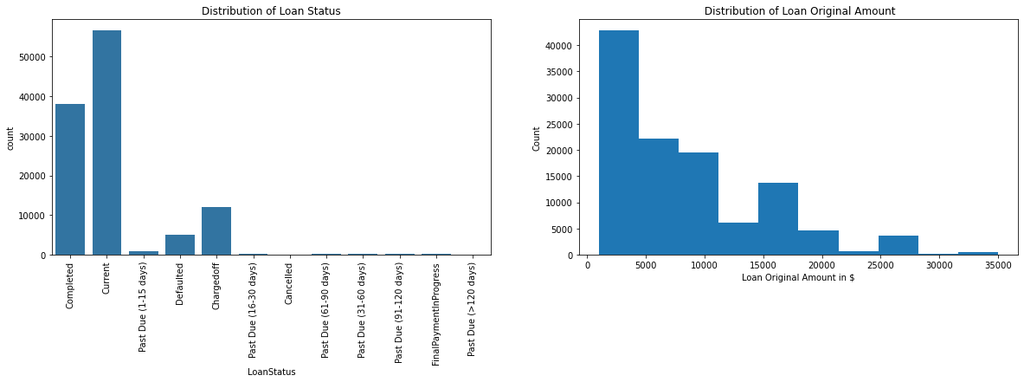

```python
# Time to plot
plt.figure(figsize=(20,5))

plt.subplot(1, 2, 1)
sb.countplot(data=df,x='LoanStatus',color = sb.color_palette()[0])
plt.title('Distribution of Loan Status')
plt.xticks(rotation=90);

plt.subplot(1, 2, 2)
plt.hist(data = df, x = 'LoanOriginalAmount')
plt.title(' Distribution of Loan Original Amount')
plt.xlabel('Loan Original Amount in $')
plt.ylabel('Count')
plt.show()
```

**Will a log transformation show more details about the above distribution?**

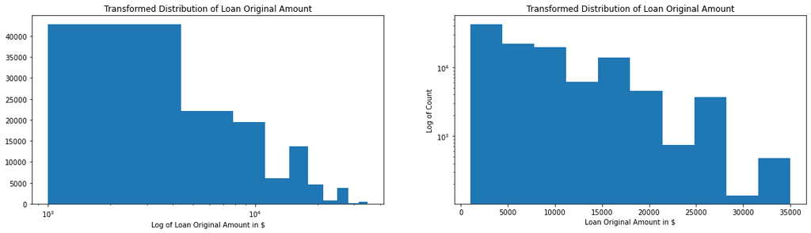

```python
# TIme to see some transformations for deeper depicting of distribution
plt.figure(figsize=(20,5))

plt.subplot(1, 2, 1)
plt.hist(data = df, x = 'LoanOriginalAmount')
plt.xlabel('Log of Loan Original Amount in $')
plt.title('Transformed Distribution of Loan Original Amount')
plt.xscale('log')

plt.subplot(1, 2, 2)
plt.hist(data = df, x = 'LoanOriginalAmount')
plt.xlabel('Loan Original Amount in $')
plt.ylabel('Log of Count')
plt.title('Transformed Distribution of Loan Original Amount')
plt.yscale('log')
plt.show()
```

**What does the distribution of the selected boolean variables in this dataset look like?**

> Let's plot all Categorical variables we are interested in to see their distribution.

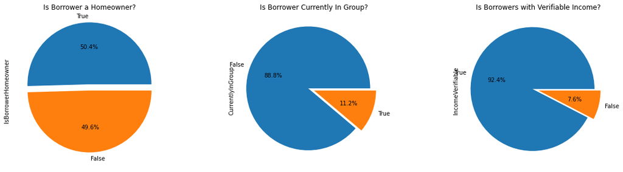

```python
#I will plot the boolean values first with a pie chart
fig, ax = plt.subplots(ncols=3,figsize = [20,5])

df['IsBorrowerHomeowner'].value_counts().plot(kind='pie',autopct='%1.1f%%', title='Is Borrower a Homeowner?',ax=ax[0],explode=(0.1,0))
df['CurrentlyInGroup'].value_counts().plot(kind='pie',autopct='%1.1f%%',title='Is Borrower Currently In Group?',ax=ax[1],explode=(0.1,0))
df['IncomeVerifiable'].value_counts().plot(kind='pie',autopct='%1.1f%%', title='Is Borrowers with Verifiable Income?',ax=ax[2],explode=(0.1,0))

plt.show()
```

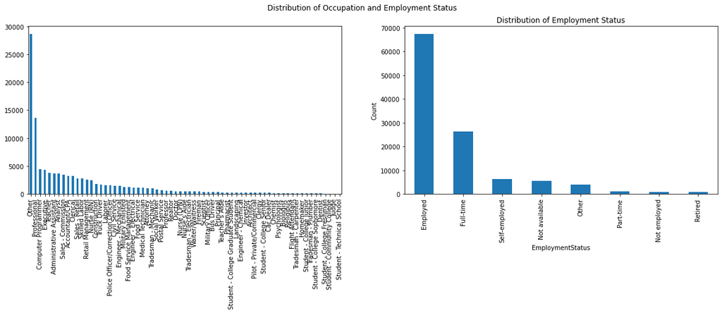

```python
#Then plot the rest as a bar chart to depict distribution better
fig, ax = plt.subplots(ncols=2,figsize = [20,5])
fig.suptitle('Distribution of Occupation and Employment Status')

df['Occupation'].value_counts().plot(kind='bar',ax=ax[0])
plt.title('Distribution of Occupation')
plt.ylabel('Count')
plt.title('Distribution of Occupation')
plt.xlabel('Occupation')
plt.xticks(rotation=90);

df['EmploymentStatus'].value_counts().plot(kind='bar',ax=ax[1])
plt.title('Distribution of Employment Status')
plt.ylabel('Count')
plt.xlabel('EmploymentStatus')
plt.xticks(rotation=90);
```

**The distribution of occupation is not making much sense as there are clustered xtick labels which makes the distribution hard to depict. To solve this problem, I am going to pick the highest 10 occurancies in this dataset and that is what I am goiing to be using subsequently.**

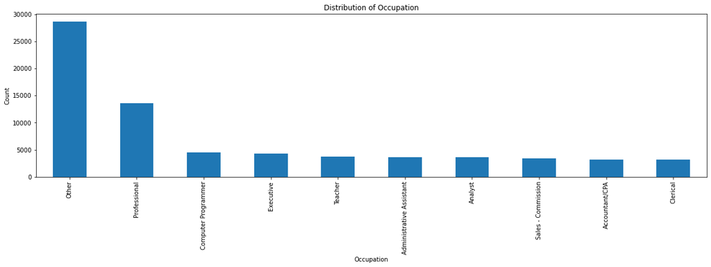

```python
# To get a beter view of the Occupation variable let's see the distribution of the highest 10
df['Occupation'].value_counts().head(10).plot(kind='bar',figsize=(20,5))
plt.title('Distribution of Occupation')
plt.ylabel('Count')
plt.xlabel('Occupation')
plt.xticks(rotation=90);
```

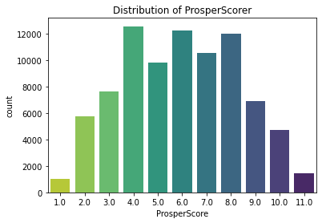

```python
#Then distribution of Prosper Score

sb.countplot(data=df,x='ProsperScore',palette='viridis_r')
plt.title('Distribution of ProsperScorer');
```

*NB:* From the Prosper Loan Data variable defintions, ProsperScore is keyed according to Prosper rating (Alpha)

### Distribution and Transformation Report on Variables of Interest in this Dataset.

> **Loan Status:** I found out that the Current loan is the most frequent followed by Completed, Chargedoff, Defaulted Past due(1-15 days), etc. This analysis will focus on the top five most occurring statuses.

> **Loan Original Amount:** The distribution is multimodal, and shows a right skewness. More loans were collected at amounts between $0-11,000. Using a log transformation on both axes one at a time, it can be seen that; (a) X-axis log transformation shows that more loans were collected between (S1000-10000) (b) Y-axis log transformation shows more skewness to the right and multimodal distribution compared to X-axis log transformation.

> **Boolean Variables:** 50.4% of borrowers are homeowners,11.2% are currently in a group,92.4% are with verifiable income source while 49.6% are not homeowners,88.8% are not currently in a group and 7.6% don't have a verifiable income source.

> **Occupation:** there are a lot of categories in this variable, so I visualized the 10 most occurring in this dataset to streamline further analysis.

> **Employment Status:** As I expected, this follows an order that shows that most borrowers are actively employed. This can be a result of the company giving loans to those that are actively employed than those that are inactive.

> **Prosper Score:** the distribution does not follow a particular pattern but scores of 4,6, and 8 occurred mostly.

## Bivariate Exploration

> **In this section,I will investigate relationships between pairs of variables that have been introduced in the previous section (univariate exploration).**

> **What type of Relationship occur between Prosper Score and other variables of interest?**

### Let's see the relationship between Loan Prosper Score and variables of interest below

**Let's see the relationship between Loan Prosper Score and boolean variables below**

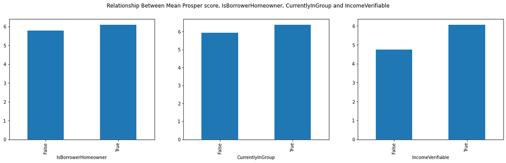

```python
fig, ax = plt.subplots(ncols=3,figsize = [20,5])
fig.suptitle('Relationship Between Mean Prosper score, IsBorrowerHomeowner, CurrentlyInGroup and IncomeVerifiable')

df.groupby('IsBorrowerHomeowner').mean().ProsperScore.plot(kind='bar',ax=ax[0])
df.groupby('CurrentlyInGroup').mean().ProsperScore.plot(kind='bar',ax=ax[1])
df.groupby('IncomeVerifiable').mean().ProsperScore.plot(kind='bar',ax=ax[2]);
```

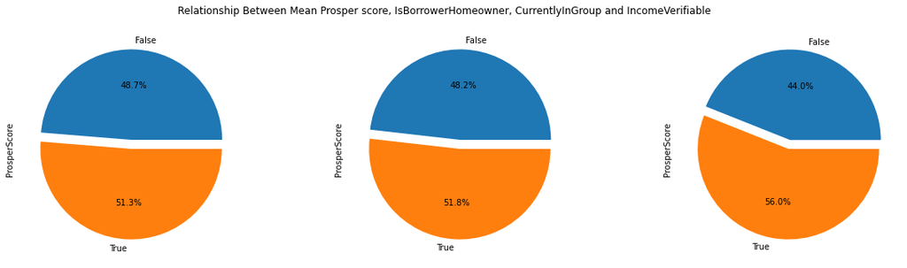

```python
# Let me see what it looks like on a pie chart using percentage
fig, ax = plt.subplots(ncols=3,figsize = [20,5])
fig.suptitle('Relationship Between Mean Prosper score, IsBorrowerHomeowner, CurrentlyInGroup and IncomeVerifiable')

df.groupby('IsBorrowerHomeowner').mean().ProsperScore.plot(kind='pie',ax=ax[0],autopct='%1.1f%%',explode=(0.1,0))
df.groupby('CurrentlyInGroup').mean().ProsperScore.plot(kind='pie',ax=ax[1],autopct='%1.1f%%',explode=(0.1,0))
df.groupby('IncomeVerifiable').mean().ProsperScore.plot(kind='pie',ax=ax[2],autopct='%1.1f%%',explode=(0.1,0));
```

> **I will create a 500 random samples(df1) of this dataset, then create two(2) new datasets(new_ls and new_es).**

```python
#Random Sampling
np.random.seed(1)
df1=df.sample(500)
```

```python
#Creating of new table from our dataset which contains Loan status and occupation that occured most in our dataset(new_ls and new_es respectively)
new_ls= df.loc[df['LoanStatus'].isin(['Current','Completed','Chargedoff','Defaulted','Past Due(1-15 days)'])]
new_es= df.loc[df['Occupation'].isin(['Other','Professional','Computer Programmer','Executive','Teacher','Analyst'])]
```

```
No artists with labels found to put in legend.  Note that artists whose label start with an underscore are ignored when legend() is called with no argument.
```

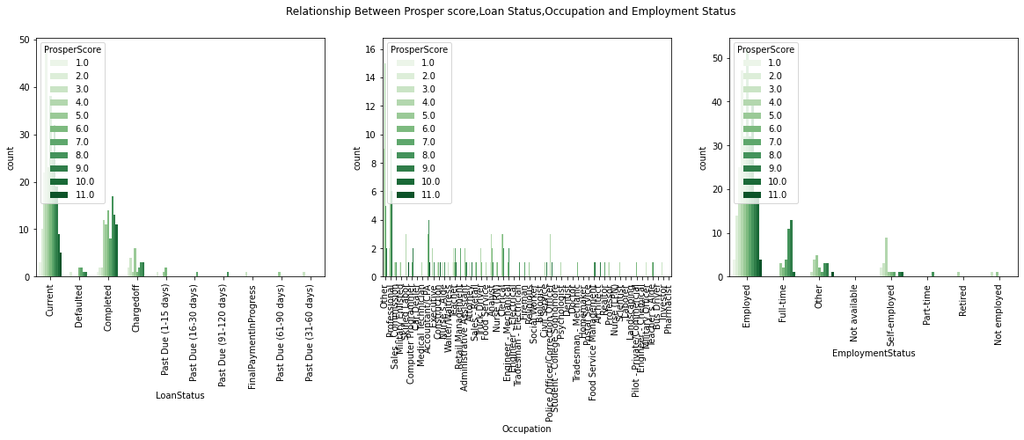

```python
# for the random samples, I want to examine Relationship Between Prosper score,Loan Status,Occupation and Employment Status
fig, ax = plt.subplots(ncols=3,figsize=(20,5))
for tick in ax[1].get_xticklabels():
    tick.set_rotation(90)
fig.suptitle('Relationship Between Prosper score,Loan Status,Occupation and Employment Status')

plt.xticks(rotation=90)
plt.legend(loc='upper right')

z1=sb.countplot(data = df1, hue= 'ProsperScore', x= 'LoanStatus', palette = 'Greens',ax=ax[0])
z1.set_xticklabels(z1.get_xticklabels(),rotation=90)

sb.countplot(data = df1, hue= 'ProsperScore', x= 'Occupation', palette = 'Greens',ax=ax[1])


sb.countplot(data = df1, hue = 'ProsperScore', x = 'EmploymentStatus', palette = 'Greens',ax=ax[2])
plt.show()
```

> Oh! that does not look accurate to depict from, let's see what that our the new datasets looks like

```
No artists with labels found to put in legend.  Note that artists whose label start with an underscore are ignored when legend() is called with no argument.
```

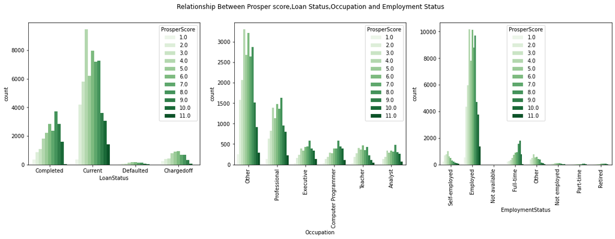

```python
# from the new table,let me compare the Prosper Score vs LoanStatus and Occupation
fig, ax = plt.subplots(ncols=3,figsize=(20,5))
plt.xticks(rotation=90)
for tick in ax[1].get_xticklabels():
    tick.set_rotation(90)
fig.suptitle('Relationship Between Prosper score,Loan Status,Occupation and Employment Status')

plt.legend(loc='upper right')


sb.countplot(data = new_ls, hue= 'ProsperScore', x= 'LoanStatus', palette = 'Greens',ax=ax[0],)
sb.countplot(data = new_es, hue= 'ProsperScore', x= 'Occupation', palette = 'Greens',ax=ax[1])
sb.countplot(data = df, hue = 'ProsperScore', x = 'EmploymentStatus', palette = 'Greens',ax=ax[2])
plt.show()
```

**Oh the plot does not look great to depict from but it is beter than the previous,let me trying plotting seperately**

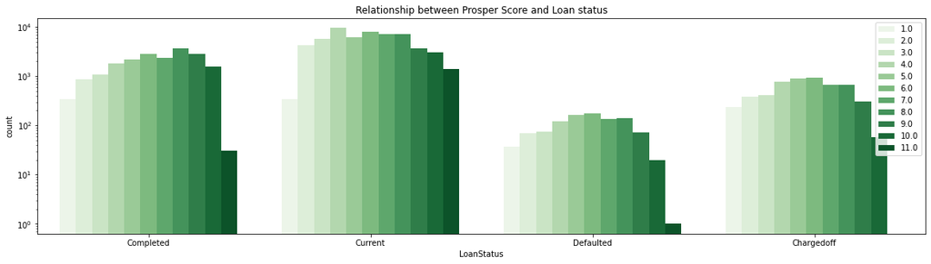

```python
plt.figure(figsize=(20,5))
sb.countplot(data = new_ls, hue= 'ProsperScore', x= 'LoanStatus', palette = 'Greens')
plt.yscale('log')
plt.title('Relationship between Prosper Score and Loan status')
plt.legend(loc='upper right');
```

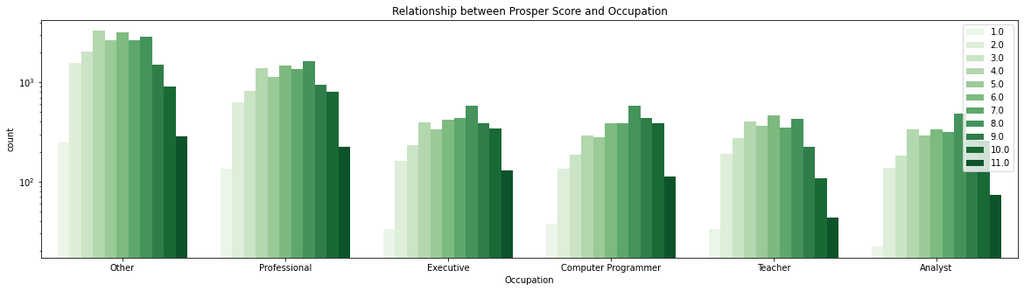

```python
plt.figure(figsize=(20,5))
sb.countplot(data = new_es, hue= 'ProsperScore', x= 'Occupation', palette = 'Greens')
plt.yscale('log')
plt.title('Relationship between Prosper Score and Occupation')
plt.legend(loc='upper right');
```

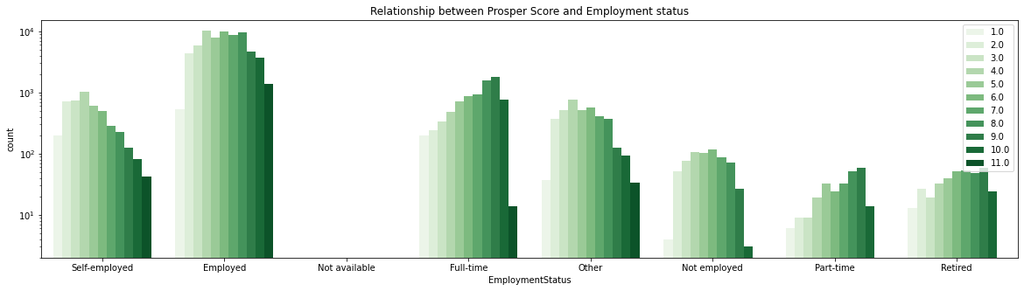

```python
plt.figure(figsize=(20,5))
sb.countplot(data = df, hue = 'ProsperScore', x = 'EmploymentStatus', palette = 'Greens')
plt.yscale('log')
plt.title('Relationship between Prosper Score and Employment status')
plt.legend(loc='upper right');
```

> **Let me try another kind of plot to see if it gets better.**

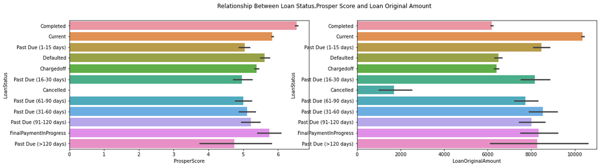

```python
fig, ax = plt.subplots(ncols=2,figsize = [20,5])
fig.suptitle('Relationship Between Loan Status,Prosper Score and Loan Original Amount')

sb.barplot(data=df,x='ProsperScore',y='LoanStatus',ax=ax[0])
sb.barplot(data=df,y='LoanStatus',x='LoanOriginalAmount',ax=ax[1])
plt.xlim(0,11000);
```

> **I will create another dataframe(loan_s) which will be used to see 'Completed','Defaulted' loan status.**

```python
loan_s= df.loc[df['LoanStatus'].isin(['Completed','Defaulted'])]
```

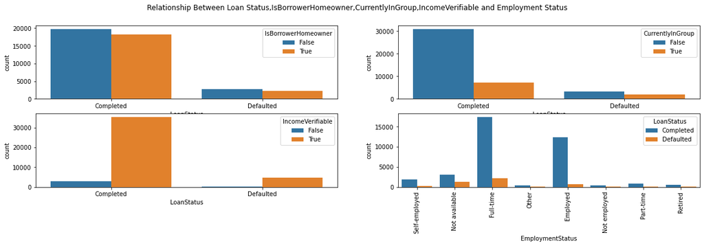

```python
fig, ax = plt.subplots(ncols=2,nrows=2,figsize = [20,5])
plt.xticks(rotation=90)

fig.suptitle('Relationship Between Loan Status,IsBorrowerHomeowner,CurrentlyInGroup,IncomeVerifiable and Employment Status')


sb.countplot(data=loan_s,hue='IsBorrowerHomeowner',x='LoanStatus',ax=ax[0,0])
sb.countplot(data=loan_s,x='LoanStatus',hue='CurrentlyInGroup',ax=ax[0,1])
sb.countplot(data=loan_s,x='LoanStatus',hue='IncomeVerifiable',ax=ax[1,0])
sb.countplot(data=loan_s,x='EmploymentStatus',hue='LoanStatus',ax=ax[1,1]);
```

> **I want to compare the Relationship between Loan Status and Employment Status of created table and randomly selected sample**

```
No artists with labels found to put in legend.  Note that artists whose label start with an underscore are ignored when legend() is called with no argument.
```

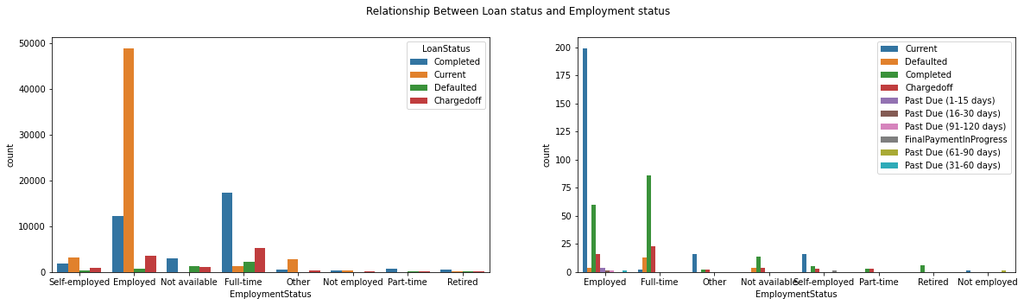

```python
fig, ax = plt.subplots(ncols=2,figsize = [20,5])
fig.suptitle('Relationship Between Loan status and Employment status')
plt.legend(loc='upper right')

sb.countplot(data=new_ls,x='EmploymentStatus',hue='LoanStatus',ax=ax[0])
sb.countplot(data=df1,x='EmploymentStatus',hue='LoanStatus',ax=ax[1]);
plt.legend(loc='upper right')
```

### **Loan Original Amount vs Categorical data**

**What can be deduced from Loan Original Amount and variables of interest?**

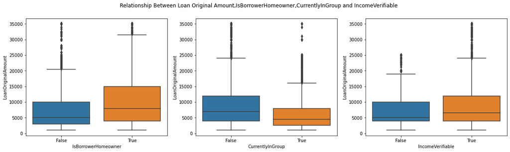

```python
#Loan original amount Vs Boolean variables
fig, ax = plt.subplots(ncols=3,figsize = [20,5])
fig.suptitle('Relationship Between Loan Original Amount,IsBorrowerHomeowner,CurrentlyInGroup and IncomeVerifiable')


sb.boxplot(data=df,x='IsBorrowerHomeowner',y='LoanOriginalAmount',ax=ax[0])
sb.boxplot(data=df,x='CurrentlyInGroup',y='LoanOriginalAmount',ax=ax[1])
sb.boxplot(data=df,x='IncomeVerifiable',y='LoanOriginalAmount',ax=ax[2]);
```

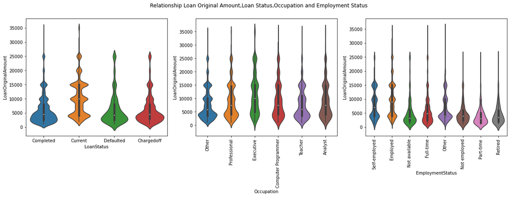

```python
#Loan original amount Vs other variables

fig, ax = plt.subplots(ncols=3,figsize = [20,5])
plt.xticks(rotation=90)
for tick in ax[1].get_xticklabels():
    tick.set_rotation(90)
fig.suptitle('Relationship Loan Original Amount,Loan Status,Occupation and Employment Status')


sb.violinplot(data=new_ls,x='LoanStatus',y='LoanOriginalAmount',ax=ax[0])
sb.violinplot(data=new_es,x='Occupation',y='LoanOriginalAmount',ax=ax[1])
sb.violinplot(data=df,x='EmploymentStatus',y='LoanOriginalAmount',ax=ax[2]);
```

> **The violin plot does not have much that I can depict from, let me see the boxplox for better insight**

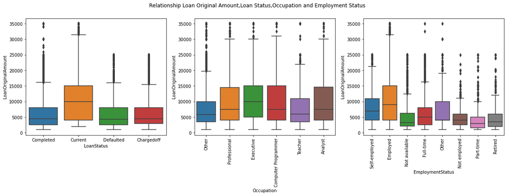

```python
fig, ax = plt.subplots(ncols=3,figsize = [20,5])
plt.xticks(rotation=90)
for tick in ax[1].get_xticklabels():
    tick.set_rotation(90)
fig.suptitle('Relationship Loan Original Amount,Loan Status,Occupation and Employment Status')

sb.boxplot(data=new_ls,x='LoanStatus',y='LoanOriginalAmount',ax=ax[0])
sb.boxplot(data=new_es,x='Occupation',y='LoanOriginalAmount',ax=ax[1])
sb.boxplot(data=df,x='EmploymentStatus',y='LoanOriginalAmount',ax=ax[2]);
```

### Observations and Relationships in the Above Bivarate Plots

> **Loan Original Amount Vs Boolean Values**

Borrowers that are homeowners, with a verifiable sources of income collected higher amounts of the loan compared to their opposites. This can result from the company seeing them as being creditworthy or giving them preference over their opposite pairs. Borrowers who are not in a group collected a higher amount of loans compared to those that are not. This can result from those in a group getting the money needed from the groups they belong to. (boxplot)

**Loan Original Amount Vs Other Variables**

Loan Status: Current borrowers have the highest amount of loan while almost the same amount was given to those with completed, charged off, and defaulters.

Occupation: Executives collected a higher amount of loan than any of the six occupations considered. Computer Programmers, Analysts, and Professionals collected almost the same amount.

Employment status: As expected, people who are actively employed collected a higher amount than those that are passively and inactively employed. (boxplot and violin plot)

## Multivariate Exploration

> I wiil create plots of three variables to further investigate these variables of interest. I want to see if Prosper Score is effective in deermining borrowers' credit worthiness.

This I will do by comparing Loan original Amount, ProsperScore and the other variables I have been working with.

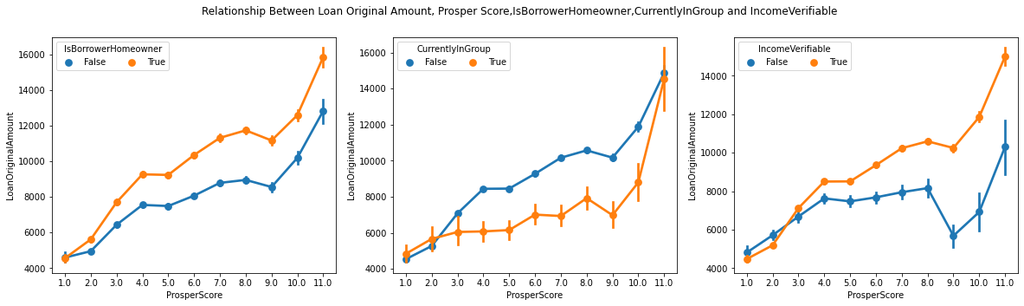

```python
fig, ax = plt.subplots(ncols=3,figsize = [20,5])
fig.suptitle('Relationship Between Loan Original Amount, Prosper Score,IsBorrowerHomeowner,CurrentlyInGroup and IncomeVerifiable')

a=sb.pointplot(data=df,hue='IsBorrowerHomeowner',y='LoanOriginalAmount',x='ProsperScore',ax=ax[0])
a.legend(loc='upper left',ncol=3,title='IsBorrowerHomeowner')

b=sb.pointplot(data=df,hue='CurrentlyInGroup',y='LoanOriginalAmount',x='ProsperScore',ax=ax[1])
b.legend(loc='upper left',ncol=3,title='CurrentlyInGroup')

c=sb.pointplot(data=df,hue='IncomeVerifiable',y='LoanOriginalAmount',x='ProsperScore',ax=ax[2])
c.legend(loc='upper left',ncol=3,title='IncomeVerifiable');
```

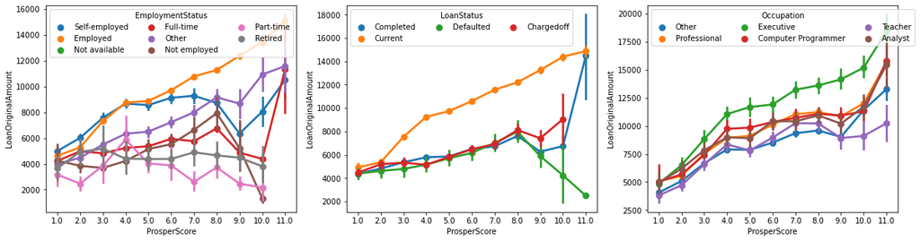

```python
fig, ax = plt.subplots(ncols=3,figsize = [20,5])
fig.suptitle('Relationship Between Loan Original Amount, Prosper Score, EmploymentStatus, LoanStatus and Occupation')

d=sb.pointplot(data=df,hue='EmploymentStatus',y='LoanOriginalAmount',x='ProsperScore',ax=ax[0])
d.legend(loc='upper left',ncol=3,title='EmploymentStatus')

e=sb.pointplot(data=new_p,hue='LoanStatus',y='LoanOriginalAmount',x='ProsperScore',ax=ax[1])
e.legend(loc='upper left',ncol=3,title='LoanStatus')

f=sb.pointplot(data=new_es,hue='Occupation',y='LoanOriginalAmount',x='ProsperScore',ax=ax[2])
f.legend(loc='upper left',ncol=3,title='Occupation');
```

> **I will like to see this relationship in another type of plot for deeper insight. I will use a regplot with fit_reg line present**

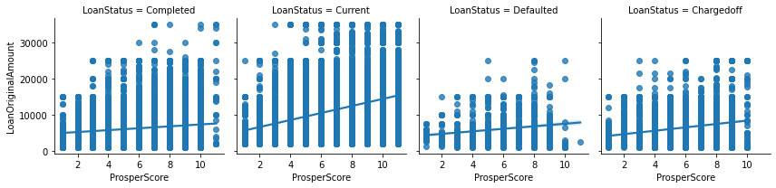

```python
fg=sb.FacetGrid(data=new_ls,col='LoanStatus')
fg.map(sb.regplot,'ProsperScore','LoanOriginalAmount')
plt.title('Relationship Between Loan Original Amount, Prosper Score and LoanStatus');
```

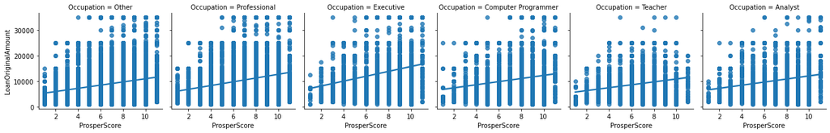

```python
fg=sb.FacetGrid(data=new_es,col='Occupation')
fg.map(sb.regplot,'ProsperScore','LoanOriginalAmount')
plt.title('Relationship Between Loan Original Amount, Prosper Score and Occupation');
```

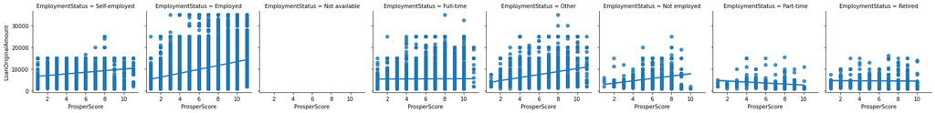

```python
fg=sb.FacetGrid(data=df,col='EmploymentStatus')
fg.map(sb.regplot,'ProsperScore','LoanOriginalAmount')
plt.title('Relationship Between Loan Original Amount, Prosper Score and EmploymentStatus');
```

### Observations and Relationships in the Above Multivariate Plots

> There is a linear relationship between Loan original amount, Prosper score, and the boolean variable being considered, following the same trend as what was observed in the bivariate plots.

> There is also a linear relationship between the Loan original amount, Prosper score, and the loan statuses been considered, this is more pronounced in the Current status as shown in the scatterplot.

> A linear relationship exists between Loan original amount, Prosper score, and all categories of Occupations considered as shown in the scatterplots.

> A linear relationship exists between the Loan original amount, Prosper score, and the employment statuses of Self-employed, employed, other, and not employed. A constant relationship exists between the Loan original amount, Prosper score, and the employment statuses of full-time and retired while there is a negative relationship between the Loan original amount, Prosper score, and part-time employment status. This didn't go as expected, I was expecting a negative correlation to exist between the Loan original amount, Prosper score, and the employment status of Not employed as we have seen in previous trends.

## Conclusions

> No system is 100% efficient as a saying goes, Prosper score prove to be effective in predicting the risk factor of giving out loans to borrowers based on the features analyzed in this project.

> There are few deviations due to the distribution of the dataset and this was accounted for at the observations at the end of each variate plot section.

> The boolean values and the features of the borrower are good to give insight on the credit worthiness of a borrower although some borrowers don't behave in a similar manner.

### Recommendation

> I recommend prosper score and the borrowers' futures analyzed in this dataset to be used to determine credit worthiness of a borrower.

> People without verifiable source of income,not currently in a group and not employed should be given a small amount of loan so as to reduce defaulting.

### Limitations

> Not all variables of this dataset were anlayzed. There was random sampling of variables as well as working on selected values in a column.

### Future Analysis

> Future analysis should consider other variables, random samples as well as deeper exploration and analysis.

### References

https://classroom.udacity.com/nanodegrees/nd002-alg-t2/parts/cd0016/modules/7e1817ca-5505-4583-b772-2e50d49a14a0/lessons/ls2236/concepts/732a5e00-5bf7-4bcc-ba1b-5c3199d4ab81

https://stackoverflow.com/questions/39714183/how-to-rotate-xticks-on-one-axis-of-figure-in-matplotlib-without-getting-the-l

https://classroom.udacity.com/nanodegrees/nd002-alg-t2/parts/cd0016/modules/7e1817ca-5505-4583-b772-2e50d49a14a0/lessons/ls2240/concepts/c192c490-40b0-4667-b2df-592cb42eaef8